# Capstone Project-How Can a Wellness Technology Company Play It Smart?

Jayanthi Manickam Sethu

2022-10-24

### This is my **Google Capstone Project**. My first data analysis project in R

**Stakeholders**  
**Urška Sršen**: Bellabeat’s cofounder and Chief Creative Officer  
**Sando Mur**: Mathematician and Bellabeat’s cofounder; key member of the Bellabeat executive team  
This analysis answers to the below questions

- What are some trends in smart device usage?
- How could these trends apply to Bellabeat customers?
- How could these trends help influence Bellabeat marketing strategy?

**Business Task**  
To deduct the trend of smart devices usage and give recommendations to improve the Bellabeat app

**Process**  
Before starting to load the files through R. I did some cleaning in the data files.

- The date format across the files was not consistent.So converted Non date dates through Data->Text to columns and formatted the date.
- I did a VLOOKUP and merged data from 2 CSV files-Got the calories data and merged in daily steps data
- There was no data for water intake. So I took data from https://www.worldometers.info/water/. It gives details about Water intake across the countries.

**Installing the necessary packages**

```r
      library(tidyverse)
      library(lubridate)
```

```r
      library(ggplot2)
      library(dplyr)
      library(grid)
      library(ggpmisc)
```

** Set the working directory **

**Read CSV Files**

```r
      # Set current working directory.
      setwd("C:/Users/Jay/OneDrive/Jay Study/Google data analytics/Capstone Project/Data/Fitabase Data 4.12.16-5.12.16")

      # Get and print current working directory.
      print(getwd())
```

```
## [1] "C:/Users/Jay/OneDrive/Jay Study/Google data analytics/Capstone Project/Data/Fitabase Data 4.12.16-5.12.16"
```

```r
      sleepData <- read.csv("sleepDay_merged.csv")
      print(is.data.frame(sleepData))
```

```
## [1] TRUE
```

```r
      print(ncol(sleepData))
```

```
## [1] 6
```

```r
      print(nrow(sleepData))
```

```
## [1] 413
```

```r
      head(sleepData)
```

```
##           Id   SleepDay TotalSleepRecords TotalMinutesAsleep TotalTimeInBed
## 1 1844505072 01-05-2016                 1                590            961
## 2 1844505072 15-04-2016                 1                644            961
## 3 3977333714 01-05-2016                 1                383            626
## 4 1844505072 30-04-2016                 1                722            961
## 5 3977333714 16-04-2016                 1                283            510
## 6 3977333714 24-04-2016                 1                310            526
##   TimeTakenToSleep
## 1              371
## 2              317
## 3              243
## 4              239
## 5              227
## 6              216
```

```r
      totalTimeTakentoSleep <- sleepData %>%
                       group_by(Id,SleepDay) %>%
                       summarise(TimeTakenToSleep = sum(TimeTakenToSleep))%>%
                       arrange(desc(TimeTakenToSleep))
```

[output not shown]

```r
      print(ncol(totalTimeTakentoSleep))
```

```
## [1] 3
```

```r
      print(nrow(totalTimeTakentoSleep))
```

```
## [1] 410
```

```r
      head(totalTimeTakentoSleep)
```

```
## # A tibble: 6 × 3
## # Groups:   Id [2]
##           Id SleepDay   TimeTakenToSleep
##        <dbl> <chr>                 <int>
## 1 1844505072 01-05-2016              371
## 2 1844505072 15-04-2016              317
## 3 3977333714 01-05-2016              243
## 4 1844505072 30-04-2016              239
## 5 3977333714 16-04-2016              227
## 6 3977333714 24-04-2016              216
```

```r
      #topTimeTakentoSleep <-head(totalTimeTakentoSleep, 5)

      # print(ncol(topTimeTakentoSleep))
      # print(nrow(topTimeTakentoSleep))
      # head(topTimeTakentoSleep)

      waterIntakeData <- read.csv("world_water_intake.csv")
      print(is.data.frame(waterIntakeData))
```

```
## [1] TRUE
```

```r
      print(ncol(waterIntakeData))
```

```
## [1] 4
```

```r
      print(nrow(waterIntakeData))
```

```
## [1] 179
```

```r
      head(waterIntakeData)
```

```
##         Country YearlyWaterUsed DailyWaterUsed Population
## 1         China          598.1B          1,165 1406847870
## 2         India          761.0B          1,689 1234281170
## 3 United States          444.3B          3,794  320878310
## 4     Indonesia          222.6B          2,332  261556381
## 5        Brazil           63.5B            844  206163053
## 6      Pakistan          183.5B          2,929  171648986
```

```r
      topwaterIntake <- head(waterIntakeData,5)


      print(ncol(topwaterIntake))
```

```
## [1] 4
```

```r
      print(nrow(topwaterIntake))
```

```
## [1] 5
```

```r
      head(topwaterIntake)
```

```
##         Country YearlyWaterUsed DailyWaterUsed Population
## 1         China          598.1B          1,165 1406847870
## 2         India          761.0B          1,689 1234281170
## 3 United States          444.3B          3,794  320878310
## 4     Indonesia          222.6B          2,332  261556381
## 5        Brazil           63.5B            844  206163053
```

```r
      calorieData <- read.csv("weightLogInfo_merged.csv")
      print(is.data.frame(calorieData))
```

```
## [1] TRUE
```

```r
      print(ncol(calorieData))
```

```
## [1] 7
```

```r
      print(nrow(calorieData))
```

```
## [1] 67
```

```r
      head(calorieData)
```

```
##           Id       Date WeightKg WeightPounds Fat   BMI  BMIStatus
## 1 1503960366 02-05-2016     52.6     115.9631  22 22.65     Normal
## 2 1503960366 03-05-2016     52.6     115.9631  NA 22.65     Normal
## 3 1927972279 13-04-2016    133.5     294.3171  NA 47.54 Overweight
## 4 2873212765 21-04-2016     56.7     125.0021  NA 21.45     Normal
## 5 2873212765 12-05-2016     57.3     126.3249  NA 21.69     Normal
## 6 4319703577 17-04-2016     72.4     159.6147  25 27.45 Overweight
```

```r
      # filterCalorieData <-calorieData %>% group_by(Id) %>%
      #                     summarise(max_WeightKg=max(WeightKg))
      # head(filterCalorieData)

      calorieStepsData <- read.csv("dailySteps_merged.csv")
      print(is.data.frame(calorieStepsData))
```

```
## [1] TRUE
```

```r
      print(ncol(calorieStepsData))
```

```
## [1] 4
```

```r
      print(nrow(calorieStepsData))
```

```
## [1] 940
```

```r
      head(calorieStepsData)
```

```
##           Id ActivityDay StepTotal TotalCaloriesBurnt
## 1 1503960366  12-04-2016     13162               1985
## 2 1503960366  13-04-2016     10735               1797
## 3 1503960366  14-04-2016     10460               1776
## 4 1503960366  15-04-2016      9762               1745
## 5 1503960366  16-04-2016     12669               1863
## 6 1503960366  17-04-2016      9705               1728
```

** Scatter Plot for Sleep pattern **

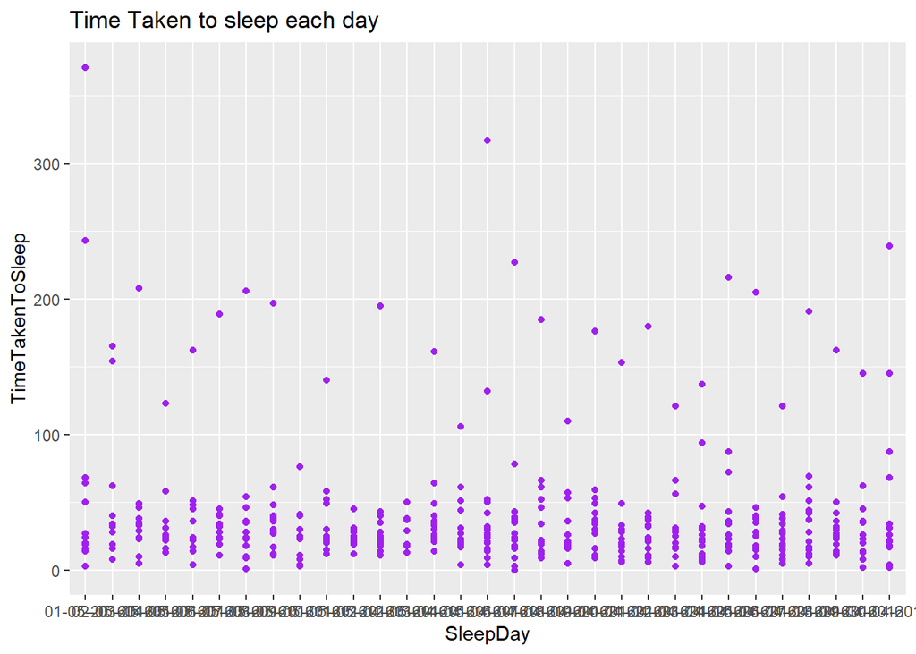

```r
ggplot(data = totalTimeTakentoSleep) +
  geom_point(mapping = aes(x =SleepDay,y= TimeTakenToSleep),color="purple")+
  ggtitle("Time Taken to sleep each day")
```

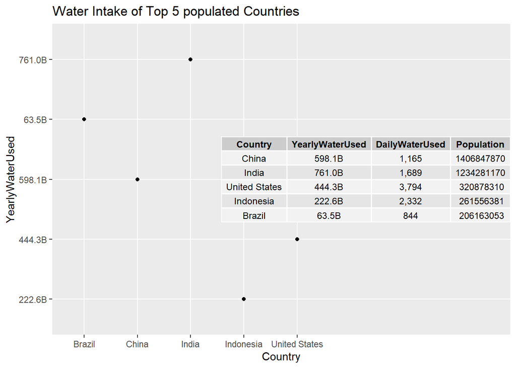

```r
ggplot(data = topwaterIntake,aes(Country, YearlyWaterUsed)) +
  geom_point() +
  annotate(geom = "table",
           x = 9,
           y = 3,
           label = list(topwaterIntake))+
  ggtitle("Water Intake of Top 5 populated Countries")
```

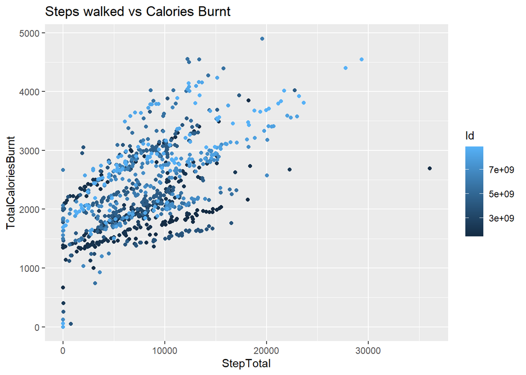

```r
# ggplot(data = calorieStepsData,aes(x=StepTotal,y=TotalCaloriesBurnt)) +
#  geom_boxplot(outlier.colour="red", outlier.shape=8,
#                 outlier.size=4)

ggplot(data = calorieStepsData) +
  geom_point(mapping = aes(x = StepTotal,y = TotalCaloriesBurnt,color=Id))+
  ggtitle("Steps walked vs Calories Burnt")
```

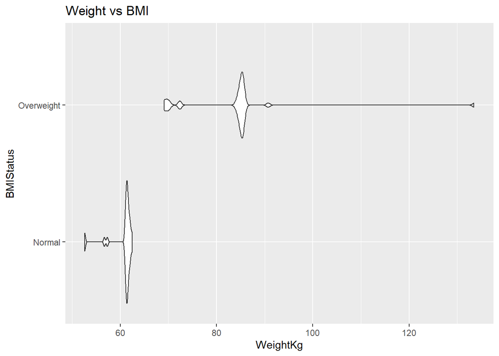

```r
  # facet_wrap(~Id)


ggplot(data = calorieData,aes(x=WeightKg,y=BMIStatus)) +
          geom_violin()+
  ggtitle("Weight vs BMI")
```

**Recommendations**

- In the smart devices, there is a feature to set reminder to drink water but if there is a feature in app to enter the measures of water intake every time the user drinks. By end of the day,the user can know the status of water intake with a status-Normal,More or Less intake.
- Should there be a provision to enter weight weekly or monthly and track BMI indicating Overweight or Normal